# Investigating-Movie-Dataset

## Project: Investigate a Dataset (TMDb_movie_data)

- Introduction
- Data Wrangling
- Exploratory Data Analysis
- Conclusions

### Introduction

```
    I analyzed TMDb_movie_dataset. I used Python libraries like pandas, numpy and matplotlib. The Dataset collects information from over 10k movies produced. It consists of different features of movies and what it took to produce it like the budget and revenue.
```

### Dataset

10866 Movie, 21 Characteristics

```
    id: Movie ID
    imdb_id: Specific Movie ID
    Popularity: Movie popularity
    Budget: Budget used for the movie
    Revenue: Total revenue spent
    Original Title: Movie Title
    Cast: Movie Casts
    HomePage: Movie HomePage
    Director: Name of Movie Director
    Tagline: Movie Tagline
    Keywords: Specific Movie Keywords
    Overview: Movie Overview
    Runtime: Total time Movie ran
    Genres: Movie Genres
    Production Companies: Companies involved in the production of the movies
    Release Date: Date the Movie was Released
    Vote Count: Number of Votes each Movie got
    Vote Average: Average Number of Votes
    Release Year: Year the Movie was Released
    Budget adj:  budget and of the associated movies in terms of 2010 dollars, accounting for inflation over time
    Revenue adj: revenue and of the associated movies in terms of 2010 dollars, accounting for inflation over time
```

### Questions for Analysis

- What Year had the most movies released and first 5 movies released in that year
- Movies produced in the 20th and 21st centuries and their increase over the years
- Movie director that has produced the most movies and the first movies produced
- Popular genres produced over the years
- Do Movies with High budgets get Higher ratings

```python
#Load useful libraries for analysis
import pandas as pd
import numpy as np
import seaborn as sns
%matplotlib inline
import matplotlib.pyplot as plt
```

## Data Wrangling

```python
#Read the dataset using pandas
df_mov = pd.read_csv('tmdb-movies.csv')

#View the first 5 rows
df_mov.head()
```

|  | id | imdb_id | popularity | budget | revenue | original_title | cast | homepage | director | tagline | ... | overview | runtime | genres | production_companies | release_date | vote_count | vote_average | release_year | budget_adj | revenue_adj |
| --- | --- | --- | --- | --- | --- | --- | --- | --- | --- | --- | --- | --- | --- | --- | --- | --- | --- | --- | --- | --- | --- |
| 0 | 135397 | tt0369610 | 32.985763 | 150000000 | 1513528810 | Jurassic World | Chris Pratt\|Bryce Dallas Howard\|Irrfan Khan\|Vi... | http://www.jurassicworld.com/ | Colin Trevorrow | The park is open. | ... | Twenty-two years after the events of Jurassic ... | 124 | Action\|Adventure\|Science Fiction\|Thriller | Universal Studios\|Amblin Entertainment\|Legenda... | 6/9/15 | 5562 | 6.5 | 2015 | 1.379999e+08 | 1.392446e+09 |
| 1 | 76341 | tt1392190 | 28.419936 | 150000000 | 378436354 | Mad Max: Fury Road | Tom Hardy\|Charlize Theron\|Hugh Keays-Byrne\|Nic... | http://www.madmaxmovie.com/ | George Miller | What a Lovely Day. | ... | An apocalyptic story set in the furthest reach... | 120 | Action\|Adventure\|Science Fiction\|Thriller | Village Roadshow Pictures\|Kennedy Miller Produ... | 5/13/15 | 6185 | 7.1 | 2015 | 1.379999e+08 | 3.481613e+08 |
| 2 | 262500 | tt2908446 | 13.112507 | 110000000 | 295238201 | Insurgent | Shailene Woodley\|Theo James\|Kate Winslet\|Ansel... | http://www.thedivergentseries.movie/#insurgent | Robert Schwentke | One Choice Can Destroy You | ... | Beatrice Prior must confront her inner demons ... | 119 | Adventure\|Science Fiction\|Thriller | Summit Entertainment\|Mandeville Films\|Red Wago... | 3/18/15 | 2480 | 6.3 | 2015 | 1.012000e+08 | 2.716190e+08 |
| 3 | 140607 | tt2488496 | 11.173104 | 200000000 | 2068178225 | Star Wars: The Force Awakens | Harrison Ford\|Mark Hamill\|Carrie Fisher\|Adam D... | http://www.starwars.com/films/star-wars-episod... | J.J. Abrams | Every generation has a story. | ... | Thirty years after defeating the Galactic Empi... | 136 | Action\|Adventure\|Science Fiction\|Fantasy | Lucasfilm\|Truenorth Productions\|Bad Robot | 12/15/15 | 5292 | 7.5 | 2015 | 1.839999e+08 | 1.902723e+09 |
| 4 | 168259 | tt2820852 | 9.335014 | 190000000 | 1506249360 | Furious 7 | Vin Diesel\|Paul Walker\|Jason Statham\|Michelle ... | http://www.furious7.com/ | James Wan | Vengeance Hits Home | ... | Deckard Shaw seeks revenge against Dominic Tor... | 137 | Action\|Crime\|Thriller | Universal Pictures\|Original Film\|Media Rights ... | 4/1/15 | 2947 | 7.3 | 2015 | 1.747999e+08 | 1.385749e+09 |

5 rows × 21 columns

The Dataset was loaded pretty nicely, now it is time to take a closer look at its properties

Things to do

- Check out its properties
- Clean the data
- Analyse the data

```python
#view the datasets dimensions
df_mov.shape
```

```
(10866, 21)
```

Without cleaning the data, the raw dataset has 10866 rows and 21 columns

```python
#View the summary of the data
df_mov.info()
```

```
<class 'pandas.core.frame.DataFrame'>
RangeIndex: 10866 entries, 0 to 10865
Data columns (total 21 columns):
 #   Column                Non-Null Count  Dtype
---  ------                --------------  -----
 0   id                    10866 non-null  int64
 1   imdb_id               10856 non-null  object
 2   popularity            10866 non-null  float64
 3   budget                10866 non-null  int64
 4   revenue               10866 non-null  int64
 5   original_title        10866 non-null  object
 6   cast                  10790 non-null  object
 7   homepage              2936 non-null   object
 8   director              10822 non-null  object
 9   tagline               8042 non-null   object
 10  keywords              9373 non-null   object
 11  overview              10862 non-null  object
 12  runtime               10866 non-null  int64
 13  genres                10843 non-null  object
 14  production_companies  9836 non-null   object
 15  release_date          10866 non-null  object
 16  vote_count            10866 non-null  int64
 17  vote_average          10866 non-null  float64
 18  release_year          10866 non-null  int64
 19  budget_adj            10866 non-null  float64
 20  revenue_adj           10866 non-null  float64
dtypes: float64(4), int64(6), object(11)
memory usage: 1.7+ MB
```

Some columns are numerical, while others are strings. Some have missing values too. As time goes on that will be fixed. Further Exploration of properties will be done.

Release Date needs to be converted into a datetime datatype

```python
#Get the statistical summary
df_mov.describe()
```

|  | id | popularity | budget | revenue | runtime | vote_count | vote_average | release_year | budget_adj | revenue_adj |
| --- | --- | --- | --- | --- | --- | --- | --- | --- | --- | --- |
| count | 10866.000000 | 10866.000000 | 1.086600e+04 | 1.086600e+04 | 10866.000000 | 10866.000000 | 10866.000000 | 10866.000000 | 1.086600e+04 | 1.086600e+04 |
| mean | 66064.177434 | 0.646441 | 1.462570e+07 | 3.982332e+07 | 102.070863 | 217.389748 | 5.974922 | 2001.322658 | 1.755104e+07 | 5.136436e+07 |
| std | 92130.136561 | 1.000185 | 3.091321e+07 | 1.170035e+08 | 31.381405 | 575.619058 | 0.935142 | 12.812941 | 3.430616e+07 | 1.446325e+08 |
| min | 5.000000 | 0.000065 | 0.000000e+00 | 0.000000e+00 | 0.000000 | 10.000000 | 1.500000 | 1960.000000 | 0.000000e+00 | 0.000000e+00 |
| 25% | 10596.250000 | 0.207583 | 0.000000e+00 | 0.000000e+00 | 90.000000 | 17.000000 | 5.400000 | 1995.000000 | 0.000000e+00 | 0.000000e+00 |
| 50% | 20669.000000 | 0.383856 | 0.000000e+00 | 0.000000e+00 | 99.000000 | 38.000000 | 6.000000 | 2006.000000 | 0.000000e+00 | 0.000000e+00 |
| 75% | 75610.000000 | 0.713817 | 1.500000e+07 | 2.400000e+07 | 111.000000 | 145.750000 | 6.600000 | 2011.000000 | 2.085325e+07 | 3.369710e+07 |
| max | 417859.000000 | 32.985763 | 4.250000e+08 | 2.781506e+09 | 900.000000 | 9767.000000 | 9.200000 | 2015.000000 | 4.250000e+08 | 2.827124e+09 |

Without proper cleaning

- The first movie was released in 1960 and last movie in 2015
- The maximum budget used for a movie is 425 million
- The longest movie runtime is 900 minuites
- Highest votes a movie has gotten is 9767

## Data Cleaning

```python
#Check for missing values
df_mov.isnull().sum()
```

```
id                         0
imdb_id                   10
popularity                 0
budget                     0
revenue                    0
original_title             0
cast                      76
homepage                7930
director                  44
tagline                 2824
keywords                1493
overview                   4
runtime                    0
genres                    23
production_companies    1030
release_date               0
vote_count                 0
vote_average               0
release_year               0
budget_adj                 0
revenue_adj                0
dtype: int64
```

Missing values will be dropped and filled Reasons

```python
#using fillna to fill the missing values
df_mov.fillna({'homepage':'No Information', 'tagline':'No Information', 'keywords':'No Information', 'production_companies':'No Information'}, inplace=True)
```

```python
#View the dataset to see if change was effective
df_mov.isnull().sum()
```

```
id                       0
imdb_id                 10
popularity               0
budget                   0
revenue                  0
original_title           0
cast                    76
homepage                 0
director                44
tagline                  0
keywords                 0
overview                 4
runtime                  0
genres                  23
production_companies     0
release_date             0
vote_count               0
vote_average             0
release_year             0
budget_adj               0
revenue_adj              0
dtype: int64
```

```python
# Dropping missing values
df_mov.dropna(inplace=True)
```

```python
#View the dataset to see if change was effective
df_mov.isnull().sum()
```

```
id                      0
imdb_id                 0
popularity              0
budget                  0
revenue                 0
original_title          0
cast                    0
homepage                0
director                0
tagline                 0
keywords                0
overview                0
runtime                 0
genres                  0
production_companies    0
release_date            0
vote_count              0
vote_average            0
release_year            0
budget_adj              0
revenue_adj             0
dtype: int64
```

All missing values have been dropped Next, features that won't be needed will be dropped

```python
#View the dimensions
df_mov.shape
```

```
(10725, 21)
```

```python
#Drop columns that won't be needed
df_mov.drop(labels=['homepage', 'keywords'], inplace=True, axis=1)
```

```python
#view to see if change was effective
df_mov.columns
```

```
Index(['id', 'imdb_id', 'popularity', 'budget', 'revenue', 'original_title',
       'cast', 'director', 'tagline', 'overview', 'runtime', 'genres',
       'production_companies', 'release_date', 'vote_count', 'vote_average',
       'release_year', 'budget_adj', 'revenue_adj'],
      dtype='object')
```

```python
#view the datatypes
df_mov.dtypes
```

```
id                        int64
imdb_id                  object
popularity              float64
budget                    int64
revenue                   int64
original_title           object
cast                     object
director                 object
tagline                  object
overview                 object
runtime                   int64
genres                   object
production_companies     object
release_date             object
vote_count                int64
vote_average            float64
release_year              int64
budget_adj              float64
revenue_adj             float64
dtype: object
```

```python
#view dimensions
df_mov.shape
```

```
(10725, 19)
```

```python
#change release date to datetime series
df_mov['release_date'] = pd.to_datetime(df_mov['release_date'])
```

```python
#view new data types
df_mov.dtypes
```

```
id                               int64
imdb_id                         object
popularity                     float64
budget                           int64
revenue                          int64
original_title                  object
cast                            object
director                        object
tagline                         object
overview                        object
runtime                          int64
genres                          object
production_companies            object
release_date            datetime64[ns]
vote_count                       int64
vote_average                   float64
release_year                     int64
budget_adj                     float64
revenue_adj                    float64
dtype: object
```

```python
df_mov['release_date'].dtypes
```

```
dtype('<M8[ns]')
```

Check for duplicates

```python
df_mov.duplicated().sum()
```

```
1
```

```python
# Drop duplicates
df_mov.drop_duplicates(inplace=True)
```

```python
#confirm change
df_mov.duplicated().sum()
```

```
0
```

### Visualizations

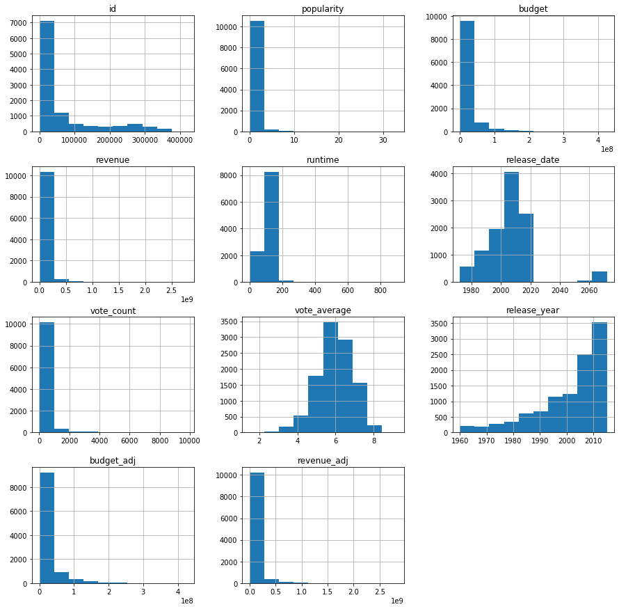

```python
#View dataset with histogram
df_mov.hist(figsize=(15,15));
```

#### Observations

Features that skewer to the right; everything except vote average and release year

Movies were released most in years between 2000 and 2020

#### Year that had the most movies released

```python
df_mov.head()
```

|  | id | imdb_id | popularity | budget | revenue | original_title | cast | director | tagline | overview | runtime | genres | production_companies | release_date | vote_count | vote_average | release_year | budget_adj | revenue_adj |
| --- | --- | --- | --- | --- | --- | --- | --- | --- | --- | --- | --- | --- | --- | --- | --- | --- | --- | --- | --- |
| 0 | 135397 | tt0369610 | 32.985763 | 150000000 | 1513528810 | Jurassic World | Chris Pratt\|Bryce Dallas Howard\|Irrfan Khan\|Vi... | Colin Trevorrow | The park is open. | Twenty-two years after the events of Jurassic ... | 124 | Action\|Adventure\|Science Fiction\|Thriller | Universal Studios\|Amblin Entertainment\|Legenda... | 2015-06-09 | 5562 | 6.5 | 2015 | 1.379999e+08 | 1.392446e+09 |
| 1 | 76341 | tt1392190 | 28.419936 | 150000000 | 378436354 | Mad Max: Fury Road | Tom Hardy\|Charlize Theron\|Hugh Keays-Byrne\|Nic... | George Miller | What a Lovely Day. | An apocalyptic story set in the furthest reach... | 120 | Action\|Adventure\|Science Fiction\|Thriller | Village Roadshow Pictures\|Kennedy Miller Produ... | 2015-05-13 | 6185 | 7.1 | 2015 | 1.379999e+08 | 3.481613e+08 |
| 2 | 262500 | tt2908446 | 13.112507 | 110000000 | 295238201 | Insurgent | Shailene Woodley\|Theo James\|Kate Winslet\|Ansel... | Robert Schwentke | One Choice Can Destroy You | Beatrice Prior must confront her inner demons ... | 119 | Adventure\|Science Fiction\|Thriller | Summit Entertainment\|Mandeville Films\|Red Wago... | 2015-03-18 | 2480 | 6.3 | 2015 | 1.012000e+08 | 2.716190e+08 |
| 3 | 140607 | tt2488496 | 11.173104 | 200000000 | 2068178225 | Star Wars: The Force Awakens | Harrison Ford\|Mark Hamill\|Carrie Fisher\|Adam D... | J.J. Abrams | Every generation has a story. | Thirty years after defeating the Galactic Empi... | 136 | Action\|Adventure\|Science Fiction\|Fantasy | Lucasfilm\|Truenorth Productions\|Bad Robot | 2015-12-15 | 5292 | 7.5 | 2015 | 1.839999e+08 | 1.902723e+09 |
| 4 | 168259 | tt2820852 | 9.335014 | 190000000 | 1506249360 | Furious 7 | Vin Diesel\|Paul Walker\|Jason Statham\|Michelle ... | James Wan | Vengeance Hits Home | Deckard Shaw seeks revenge against Dominic Tor... | 137 | Action\|Crime\|Thriller | Universal Pictures\|Original Film\|Media Rights ... | 2015-04-01 | 2947 | 7.3 | 2015 | 1.747999e+08 | 1.385749e+09 |

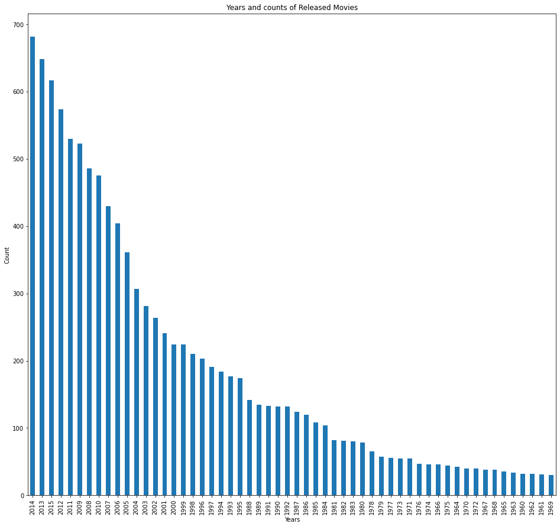

```python
#plot using bar plot
df_mov['release_year'].value_counts().plot(kind='bar', figsize=(16, 15))
plt.title('Years and counts of Released Movies')
plt.xlabel('Years')
plt.ylabel('Count');
```

This plot clearly shows that in 2014 movies were produced the most

#### Next, Get top 5 movies produced in 2014

```python
#Filter dataset to only contain movies produced in 2014
df_mov14 = df_mov[df_mov['release_year'] == 2014]
```

```python
df_mov14.head()
```

|  | id | imdb_id | popularity | budget | revenue | original_title | cast | director | tagline | overview | runtime | genres | production_companies | release_date | vote_count | vote_average | release_year | budget_adj | revenue_adj |
| --- | --- | --- | --- | --- | --- | --- | --- | --- | --- | --- | --- | --- | --- | --- | --- | --- | --- | --- | --- |
| 629 | 157336 | tt0816692 | 24.949134 | 165000000 | 621752480 | Interstellar | Matthew McConaughey\|Jessica Chastain\|Anne Hath... | Christopher Nolan | Mankind was born on Earth. It was never meant ... | Interstellar chronicles the adventures of a gr... | 169 | Adventure\|Drama\|Science Fiction | Paramount Pictures\|Legendary Pictures\|Warner B... | 2014-11-05 | 6498 | 8.0 | 2014 | 1.519800e+08 | 5.726906e+08 |
| 630 | 118340 | tt2015381 | 14.311205 | 170000000 | 773312399 | Guardians of the Galaxy | Chris Pratt\|Zoe Saldana\|Dave Bautista\|Vin Dies... | James Gunn | All heroes start somewhere. | Light years from Earth, 26 years after being a... | 121 | Action\|Science Fiction\|Adventure | Marvel Studios\|Moving Picture Company (MPC)\|Bu... | 2014-07-30 | 5612 | 7.9 | 2014 | 1.565855e+08 | 7.122911e+08 |
| 631 | 100402 | tt1843866 | 12.971027 | 170000000 | 714766572 | Captain America: The Winter Soldier | Chris Evans\|Scarlett Johansson\|Sebastian Stan\|... | Joe Russo\|Anthony Russo | In heroes we trust. | After the cataclysmic events in New York with ... | 136 | Action\|Adventure\|Science Fiction | Marvel Studios | 2014-03-20 | 3848 | 7.6 | 2014 | 1.565855e+08 | 6.583651e+08 |
| 632 | 245891 | tt2911666 | 11.422751 | 20000000 | 78739897 | John Wick | Keanu Reeves\|Michael Nyqvist\|Alfie Allen\|Wille... | Chad Stahelski\|David Leitch | Don't set him off. | After the sudden death of his beloved wife, Jo... | 101 | Action\|Thriller | Thunder Road Pictures\|Warner Bros.\|87Eleven\|De... | 2014-10-22 | 2712 | 7.0 | 2014 | 1.842182e+07 | 7.252661e+07 |
| 633 | 131631 | tt1951265 | 10.739009 | 125000000 | 752100229 | The Hunger Games: Mockingjay - Part 1 | Jennifer Lawrence\|Josh Hutcherson\|Liam Hemswor... | Francis Lawrence | Fire burns brighter in the darkness | Katniss Everdeen reluctantly becomes the symbo... | 123 | Science Fiction\|Adventure\|Thriller | Lionsgate\|Color Force | 2014-11-18 | 3590 | 6.6 | 2014 | 1.151364e+08 | 6.927528e+08 |

```python
#use groupby function to get the first 5 movies in 2014
top_5_mov14 = df_mov14.groupby(['release_date'])['original_title'].value_counts().head()
top_5_mov14
```

```
release_date  original_title
2014-01-01    Avalanche Sharks    1
2014-01-02    The Zero Theorem    1
2014-01-03    Jamesy Boy          1
2014-01-06    The 7:39            1
2014-01-08    Devil's Due         1
Name: original_title, dtype: int64
```

Using groupby() function, the first 5 movies to be produced in 2014 have ben filtered out with the help of release date

#### Movies produced in the 20th and 21st centuries and their increase over the years

```python
#filter the release years and group into 20th and 21st century
century_20 = df_mov[df_mov['release_year'] <= 2000]
century_21 = df_mov[df_mov['release_year'] > 2000]
```

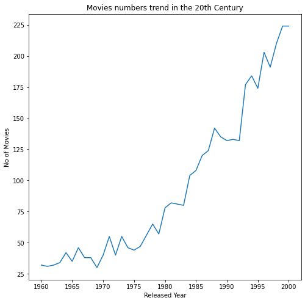

```python
#using a line plot to visualize the amount of movies released in both centuries
century_20.groupby('release_year').count().original_title.plot(kind='line',figsize=(8,8))
plt.xlabel('Released Year')
plt.ylabel('No of Movies')
plt.title('Movies numbers trend in the 20th Century');
```

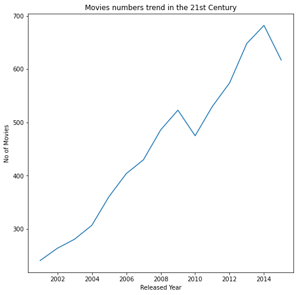

```python
#using a line plot to visualize the amount of movies released in both centuries
century_21.groupby('release_year').count().original_title.plot(kind='line',figsize=(8,8))
plt.xlabel('Released Year')
plt.ylabel('No of Movies')
plt.title('Movies numbers trend in the 21st Century');
```

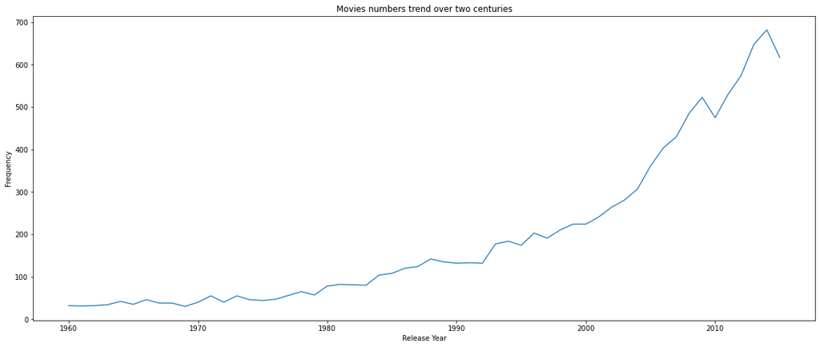

```python
#plot a line plot to show the movie releases in both centuries
df_mov.groupby('release_year').count().original_title.plot(kind='line', alpha=0.9,figsize=(20,8))
plt.xlabel('Release Year')
plt.ylabel('Frequency')
plt.title('Movies numbers trend over two centuries');
```

```python
#total movies released in the 20th century
century_20_sum = century_20.count().original_title
century_20_sum
```

```
3901
```

```python
#total movies released in the 21st century
century_21_sum = century_21.count().original_title
century_21_sum
```

```
6823
```

#### Movie Director that made the most Movies

```python
#Get the director with the highest number of occurences in the dataframe
Top_dir = df_mov['director'].value_counts().head(1)
Top_dir
```

```
Woody Allen    45
Name: director, dtype: int64
```

Woody Allen made the most movies

Next, the years and movie titles he produced will be gotten

```python
#filter to only include features/columns that only contain movies Woody Allen directed
mov_wa = df_mov[df_mov['director'] == 'Woody Allen']
mov_wa.head()
```

|  | id | imdb_id | popularity | budget | revenue | original_title | cast | director | tagline | overview | runtime | genres | production_companies | release_date | vote_count | vote_average | release_year | budget_adj | revenue_adj |
| --- | --- | --- | --- | --- | --- | --- | --- | --- | --- | --- | --- | --- | --- | --- | --- | --- | --- | --- | --- |
| 155 | 282984 | tt3715320 | 1.007054 | 11000000 | 27391084 | Irrational Man | Emma Stone\|Joaquin Phoenix\|Jamie Blackley\|Park... | Woody Allen | No Information | On a small town college campus, a philosophy p... | 95 | Mystery\|Drama | Sony Pictures\|Gravier Productions | 2015-07-17 | 319 | 6.1 | 2015 | 1.012000e+07 | 2.519979e+07 |
| 790 | 229297 | tt2870756 | 0.889247 | 0 | 32339326 | Magic in the Moonlight | Colin Firth\|Emma Stone\|Hamish Linklater\|Marcia... | Woody Allen | No Information | Set in the 1920s French Riviera, a master magi... | 97 | Comedy\|Drama\|Romance | Perdido Productions\|Harbor Picture Company | 2014-07-25 | 464 | 6.3 | 2014 | 0.000000e+00 | 2.978746e+07 |
| 1332 | 703 | tt0075686 | 1.179653 | 4000000 | 38251425 | Annie Hall | Woody Allen\|Diane Keaton\|Tony Roberts\|Carol Ka... | Woody Allen | A nervous romance. | In the city of New York, comedian Alvy Singer ... | 93 | Comedy\|Drama\|Romance | United Artists | 1977-04-19 | 493 | 7.6 | 1977 | 1.439112e+07 | 1.376203e+08 |
| 1489 | 19265 | tt1178663 | 0.804857 | 15000000 | 0 | Whatever Works | Larry David\|Evan Rachel Wood\|Adam Brooks\|Micha... | Woody Allen | A new comedy | Whatever Works explores the relationship betwe... | 92 | Comedy\|Romance | Sony Pictures Classics\|Wild Bunch\|Gravier Prod... | 2009-06-19 | 174 | 6.7 | 2009 | 1.524601e+07 | 0.000000e+00 |
| 2126 | 38031 | tt1182350 | 0.493121 | 22000000 | 0 | You Will Meet a Tall Dark Stranger | Naomi Watts\|Josh Brolin\|Antonio Banderas\|Ewen ... | Woody Allen | No Information | Two married couples find only trouble and hear... | 98 | Comedy\|Drama\|Romance | Antena 3 Films | 2010-05-23 | 131 | 5.8 | 2010 | 2.200000e+07 | 0.000000e+00 |

```python
#filter to only display movies and release years
mov_wa[['original_title', 'release_year']]
```

|  | original_title | release_year |
| --- | --- | --- |
| 155 | Irrational Man | 2015 |
| 790 | Magic in the Moonlight | 2014 |
| 1332 | Annie Hall | 1977 |
| 1489 | Whatever Works | 2009 |
| 2126 | You Will Meet a Tall Dark Stranger | 2010 |
| 2551 | Sweet and Lowdown | 1999 |
| 2744 | The Curse of the Jade Scorpion | 2001 |
| 2964 | Vicky Cristina Barcelona | 2008 |
| 3429 | Midnight in Paris | 2011 |
| 4046 | Hollywood Ending | 2002 |
| 4250 | Bullets Over Broadway | 1994 |
| 4493 | To Rome with Love | 2012 |
| 5079 | Anything Else | 2003 |
| 5310 | Deconstructing Harry | 1997 |
| 5551 | Blue Jasmine | 2013 |
| 6116 | The Purple Rose of Cairo | 1985 |
| 6248 | Match Point | 2005 |
| 6721 | Scoop | 2006 |
| 7121 | Melinda and Melinda | 2004 |
| 7278 | Everything You Always Wanted to Know About Sex... | 1972 |
| 7355 | Stardust Memories | 1980 |
| 7553 | Cassandra's Dream | 2007 |
| 7835 | Manhattan | 1979 |
| 7978 | Broadway Danny Rose | 1984 |
| 8020 | Zelig | 1983 |
| 8119 | Mighty Aphrodite | 1995 |
| 8354 | Husbands and Wives | 1992 |
| 8505 | Everyone Says I Love You | 1996 |
| 8741 | Small Time Crooks | 2000 |
| 8917 | A Midsummer Night's Sex Comedy | 1982 |
| 9075 | Celebrity | 1998 |
| 9238 | Crimes and Misdemeanors | 1989 |
| 9372 | Shadows and Fog | 1991 |
| 9491 | Another Woman | 1988 |
| 9640 | Radio Days | 1987 |
| 9667 | September | 1987 |
| 9817 | Love and Death | 1975 |
| 9941 | Bananas | 1971 |
| 10030 | Alice | 1990 |
| 10257 | Manhattan Murder Mystery | 1993 |
| 10519 | Hannah and Her Sisters | 1986 |
| 10609 | Sleeper | 1973 |
| 10729 | Take the Money and Run | 1969 |
| 10804 | Interiors | 1978 |
| 10864 | What's Up, Tiger Lily? | 1966 |

Filter further to get the top 5 movies, genres and the years they were produced

```python
#use groupby to get first 5 movies, genres and years Woody Allen was involved in
mov_wa.groupby('release_year')[['original_title', 'genres']].value_counts().head()
```

```
release_year  original_title                                                          genres
1966          What's Up, Tiger Lily?                                                  Action|Comedy                     1
1969          Take the Money and Run                                                  Comedy|Crime                      1
1971          Bananas                                                                 Comedy                            1
1972          Everything You Always Wanted to Know About Sex *But Were Afraid to Ask  Comedy                            1
1973          Sleeper                                                                 Science Fiction|Comedy|Romance    1
dtype: int64
```

#### Which genres are most popular from year to year?

```python
#use split() to split the genres since a row has multiple genres
#copy the dataframe into a new one
df_new = df_mov.copy()

#using split() function to seperate the genres in a single row
df_new['genres'] = df_new['genres'].str.split('|')

#a new row can be created to contain the splited genres using explode
df_new = df_new.explode('genres')

#filter to get only the popularity, genres and release year columns
pop_genre = df_new[['popularity', 'genres', 'release_year']]

#using groupby to get the most popular genres each year
pop_genre.groupby(['release_year', 'genres'])['popularity'].mean().groupby(level='release_year').nlargest(1).reset_index(level=0, drop=True)
```

```
release_year  genres
1960          Thriller           0.811910
1961          Animation          2.631987
1962          Adventure          0.942513
1963          Animation          2.180410
1964          War                0.930959
1965          Music              0.968850
1966          Animation          0.585717
1967          Animation          2.550704
1968          Mystery            1.519456
1969          Crime              0.948020
1970          Animation          1.127719
1971          Family             1.530722
1972          Crime              1.072768
1973          Animation          0.956526
```

[output cut: 43 more lines]

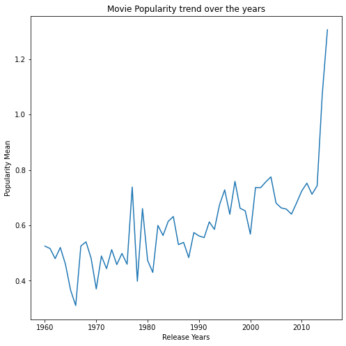

```python
#create a line plot to view the movie release trend
df_new.groupby('release_year').popularity.mean().plot(kind='line',figsize=(8,8))
plt.title('Movie Popularity trend over the years')
plt.xlabel('Release Years')
plt.ylabel('Popularity Mean');
```

After using groupby to get the most popular genres each year, a line plot was used to display the release trend over the years which was not so consistent and steady. The popularity rate had its first sharp decline in year 1966 but came back up in 1967. This unsteady trend continued over the years till 2012 when the increase became constant.

### Do Movies with High budgets get Higher ratings

```python
df_mov.head()
```

|  | id | imdb_id | popularity | budget | revenue | original_title | cast | director | tagline | overview | runtime | genres | production_companies | release_date | vote_count | vote_average | release_year | budget_adj | revenue_adj |
| --- | --- | --- | --- | --- | --- | --- | --- | --- | --- | --- | --- | --- | --- | --- | --- | --- | --- | --- | --- |
| 0 | 135397 | tt0369610 | 32.985763 | 150000000 | 1513528810 | Jurassic World | Chris Pratt\|Bryce Dallas Howard\|Irrfan Khan\|Vi... | Colin Trevorrow | The park is open. | Twenty-two years after the events of Jurassic ... | 124 | Action\|Adventure\|Science Fiction\|Thriller | Universal Studios\|Amblin Entertainment\|Legenda... | 2015-06-09 | 5562 | 6.5 | 2015 | 1.379999e+08 | 1.392446e+09 |
| 1 | 76341 | tt1392190 | 28.419936 | 150000000 | 378436354 | Mad Max: Fury Road | Tom Hardy\|Charlize Theron\|Hugh Keays-Byrne\|Nic... | George Miller | What a Lovely Day. | An apocalyptic story set in the furthest reach... | 120 | Action\|Adventure\|Science Fiction\|Thriller | Village Roadshow Pictures\|Kennedy Miller Produ... | 2015-05-13 | 6185 | 7.1 | 2015 | 1.379999e+08 | 3.481613e+08 |
| 2 | 262500 | tt2908446 | 13.112507 | 110000000 | 295238201 | Insurgent | Shailene Woodley\|Theo James\|Kate Winslet\|Ansel... | Robert Schwentke | One Choice Can Destroy You | Beatrice Prior must confront her inner demons ... | 119 | Adventure\|Science Fiction\|Thriller | Summit Entertainment\|Mandeville Films\|Red Wago... | 2015-03-18 | 2480 | 6.3 | 2015 | 1.012000e+08 | 2.716190e+08 |
| 3 | 140607 | tt2488496 | 11.173104 | 200000000 | 2068178225 | Star Wars: The Force Awakens | Harrison Ford\|Mark Hamill\|Carrie Fisher\|Adam D... | J.J. Abrams | Every generation has a story. | Thirty years after defeating the Galactic Empi... | 136 | Action\|Adventure\|Science Fiction\|Fantasy | Lucasfilm\|Truenorth Productions\|Bad Robot | 2015-12-15 | 5292 | 7.5 | 2015 | 1.839999e+08 | 1.902723e+09 |
| 4 | 168259 | tt2820852 | 9.335014 | 190000000 | 1506249360 | Furious 7 | Vin Diesel\|Paul Walker\|Jason Statham\|Michelle ... | James Wan | Vengeance Hits Home | Deckard Shaw seeks revenge against Dominic Tor... | 137 | Action\|Crime\|Thriller | Universal Pictures\|Original Film\|Media Rights ... | 2015-04-01 | 2947 | 7.3 | 2015 | 1.747999e+08 | 1.385749e+09 |

[figure not shown]

```python
#create a scatter plot to show the relationship between budget and vote count
#set the plot style
plt.figure(figsize=(8,8))
sns.set(style='whitegrid')
sns.scatterplot(x='budget', y='vote_count', data=df_mov)
plt.xlabel('Budget')
plt.ylabel('Ratings')
plt.title('Relationship Between Budget and Ratings');
```

[output not shown]